# TCAC 2.0 — Topic Modelling Report

BERTopic clustering of the TCAC 2.0 corpus (UMAP + HDBSCAN)

Author

Rainer M. Krug

Published

June 30, 2026

[figure not shown]

Part of the Data Management Report

[figure not shown]

# Working Title

TCAC 2.0 — Transformative Change Assessment Corpus 2.0

## Code repo

[Github repository](https://github.com/IPBES-Data/TCAC-2.0)

# Introduction

This report documents the topic-modelling layer of TCAC 2.0. SPECTER2 embeddings of the corpus (produced and assessed in the Embedding Report) are reduced to a low-dimensional space with UMAP and clustered with HDBSCAN, using the [BERTopic](https://maartengr.github.io/BERTopic/) framework. Each work in the corpus and each keypaper is assigned a `topic_id`. Topics are summarised by per-topic c-TF-IDF vocabulary on the title + abstract text.

The full-corpus fit (~5.77 M works) runs on a RunPod GPU pod via cuml (`topics_tcac20_runpod`). Outputs are written hive-partitioned under `output/TCAC_2.0/topics/config=<emb>/bertopic=<run>/variant=<v>/`.

```r
library(targets)
library(arrow)
library(dplyr)
library(ggplot2)
library(htmltools)
library(knitr)
```

# Method

## Pipeline summary

The pipeline is orchestrated by `targets`. Stages relevant to this report:

1. **Embeddings** — SPECTER2 (768-d) on title, abstract and title+abstract variants. See the Embedding Report.
2. **UMAP** — reduce the primary variant (`title_abstract`) to `n_components = 5` dimensions for clustering, plus a 2-D projection for visualisation.
3. **HDBSCAN** — density-based clustering on the 5-D UMAP space.
4. **c-TF-IDF** — per-topic term scoring on the title+abstract text, producing the topic vocabulary.
5. **Fallback projection** — works without abstracts (and the keypapers without abstracts) are projected via the title variant onto the same UMAP+HDBSCAN fit and tagged `topic_source = "fallback"`.

## Parameters used

The BERTopic fit is identified by three things: the **embedding config** it consumes (which embedding model + which run produced the vectors), the **variant** of those embeddings used as the primary input, and the **BERTopic config** itself (UMAP + HDBSCAN + vectorizer knobs). All three are read from `input/config.yaml`.

```r
y <- yaml::read_yaml("input/config.yaml")
active_emb_cfg <- y$embeddings$active
active_btopic <- y$bertopic$active_runpod
cfg <- tar_read(bertopic_runpod_cfg)

# Show only the knobs that affect the fit (skip transport/ssh details).
knobs <- c(
  "method",
  "primary_variant",
  "fallback_variant",
  "center_embeddings",
  "umap_n_components",
  "umap_n_neighbors",
  "umap_min_dist",
  "umap_metric",
  "hdbscan_min_cluster_size",
  "hdbscan_min_samples",
  "top_n_words",
  "vectorizer_min_df",
  "vectorizer_max_df",
  "vectorizer_max_features",
  "vectorizer_ngram",
  "keypaper_threshold",
  "random_seed"
)
have <- intersect(knobs, names(cfg))

tibble::tibble(
  parameter = c("embedding config", "bertopic config", have),
  value = c(
    active_emb_cfg,
    active_btopic,
    vapply(
      have,
      function(k) {
        v <- cfg[[k]]
        if (is.null(v)) "—" else paste(v, collapse = ", ")
      },
      character(1)
    )
  )
) |>
  knitr::kable(
    caption = sprintf(
      "Active embedding config: %s · BERTopic config: %s · Primary variant: %s · Fallback variant: %s.",
      active_emb_cfg,
      active_btopic,
      cfg$primary_variant %||% "title_abstract",
      cfg$fallback_variant %||% "title"
    )
  )
```

Table 1: Active embedding config: SPECTER2_runpod · BERTopic config: runpod_v4 · Primary variant: title_abstract · Fallback variant: title.

| parameter | value |
| --- | --- |
| embedding config | SPECTER2_runpod |
| bertopic config | runpod_v4 |
| method | runpod |
| primary_variant | title_abstract |
| fallback_variant | title |
| umap_n_components | 5 |
| umap_n_neighbors | 15 |
| umap_min_dist | 0 |
| umap_metric | euclidean |
| hdbscan_min_cluster_size | 100 |
| hdbscan_min_samples | 10 |
| top_n_words | 15 |
| vectorizer_min_df | 2 |
| vectorizer_max_df | 0.95 |
| vectorizer_max_features | 20000 |
| vectorizer_ngram | 1, 2 |
| keypaper_threshold | 3 |
| random_seed | 13 |

# Results

## Topic count and corpus coverage

```r
# tar_read(topics_tcac20_runpod) returns the path to topic_info.parquet
# inside the hive-partitioned leaf
# output/TCAC_2.0/topics/config=<emb>/bertopic=<run>/variant=<v>/.
# Parse the three hive-partition keys out of the path so the report
# surfaces the active embedding config, bertopic config, and variant
# alongside the fit summary.
topic_info_path <- tar_read(topics_tcac20_runpod)
topics_dir <- dirname(topic_info_path)
parts <- strsplit(topics_dir, "/", fixed = TRUE)[[1]]
leaf_emb_cfg <- sub("^config=", "", grep("^config=", parts, value = TRUE))
leaf_btopic <- sub("^bertopic=", "", grep("^bertopic=", parts, value = TRUE))
leaf_variant <- sub("^variant=", "", grep("^variant=", parts, value = TRUE))

ti <- arrow::read_parquet(topic_info_path)
tp <- arrow::open_dataset(file.path(topics_dir, "topics.parquet"))

n_works <- nrow(tp)
n_topics <- nrow(ti)
n_noise <- ti |>
  dplyr::filter(topic_id == -1L) |>
  dplyr::summarise(n = sum(n_corpus + n_keypapers)) |>
  dplyr::pull(n)
if (length(n_noise) == 0) {
  n_noise <- 0L
}
n_topics_real <- n_topics - as.integer(any(ti$topic_id == -1L))

tibble::tibble(
  metric = c(
    "Number of topics (incl. noise -1)",
    "Number of topics (excl. noise)",
    "Works assigned to a topic",
    "Works in noise cluster (-1)",
    "Noise share (%)"
  ),
  value = c(
    format(n_topics, big.mark = ","),
    format(n_topics_real, big.mark = ","),
    format(n_works - n_noise, big.mark = ","),
    format(n_noise, big.mark = ","),
    sprintf("%.2f", 100 * n_noise / n_works)
  )
) |>
  knitr::kable(
    align = c("l", "r"),
    caption = sprintf(
      "High-level summary of the BERTopic fit (embedding config: %s · bertopic config: %s · variant: %s).",
      leaf_emb_cfg,
      leaf_btopic,
      leaf_variant
    )
  )
```

Table 2: High-level summary of the BERTopic fit (embedding config: SPECTER2_runpod · bertopic config: runpod_v4 · variant: title_abstract).

| metric | value |
| --- | --- |
| Number of topics (incl. noise -1) | 11 |
| Number of topics (excl. noise) | 10 |
| Works assigned to a topic | 5,526,940 |
| Works in noise cluster (-1) | 241,317 |
| Noise share (%) | 4.18 |

## Topic-size distribution

How is the corpus distributed across topics? A healthy fit shows many topics with roughly comparable sizes (heavy-tailed but not single-blob). A *collapsed* fit shows one topic absorbing the bulk of the corpus — easy to spot visually as one bar dwarfing the rest.

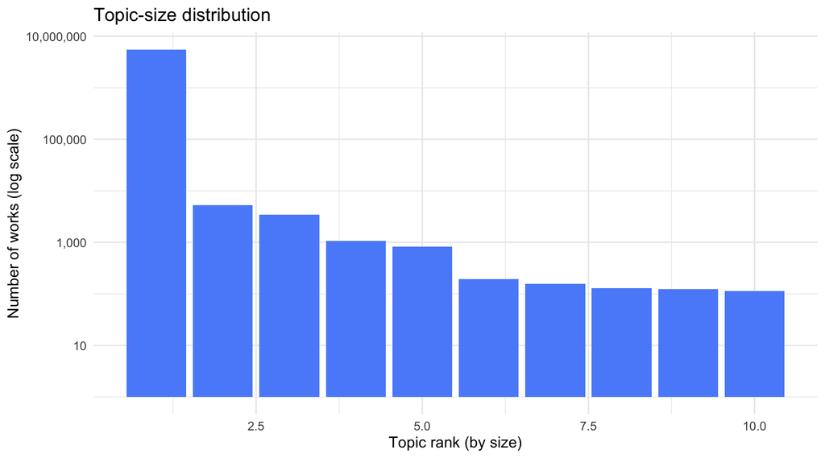

Figure 1

```r
# Placeholder: fig_topic_sizes is not yet wired as a tar_target — build
# inline from topic_info. Move to a target once the visualisation layer
# is finalised (see TODO_Visualisations.md §2).
ti |>
  dplyr::filter(topic_id >= 0L) |>
  dplyr::arrange(dplyr::desc(n_corpus)) |>
  dplyr::mutate(rank = dplyr::row_number()) |>
  ggplot2::ggplot(ggplot2::aes(x = rank, y = n_corpus)) +
  ggplot2::geom_col(fill = "#5B8FF9") +
  ggplot2::scale_y_log10(labels = scales::label_comma()) +
  ggplot2::labs(
    x = "Topic rank (by size)",
    y = "Number of works (log scale)",
    title = "Topic-size distribution"
  ) +
  ggplot2::theme_minimal(base_size = 12)
```

```r
ti |>
  dplyr::filter(topic_id >= 0L) |>
  dplyr::pull(n_corpus) |>
  quantile(probs = c(0, 0.05, 0.25, 0.5, 0.75, 0.95, 1)) |>
  tibble::enframe(name = "quantile", value = "topic size") |>
  dplyr::mutate(`topic size` = format(round(`topic size`), big.mark = ",")) |>
  knitr::kable(
    align = c("l", "r"),
    caption = "Quantiles of the topic-size distribution (noise excluded)."
  )
```

Table 3: Quantiles of the topic-size distribution (noise excluded).

| quantile | topic size |
| --- | --- |
| 0% | 114 |
| 5% | 118 |
| 25% | 137 |
| 50% | 506 |
| 75% | 2,848 |
| 95% | 3,035,904 |
| 100% | 5,515,488 |

## Topic vocabulary

For each topic: rank by size, top-N c-TF-IDF terms, count of works, count of keypapers in the topic, and the `is_relevant` flag (`n_keypapers ≥ keypaper_threshold`).

```r
tar_read(tbl_topics)
```

Table 4

| topic_id | is_relevant | n_keypapers | n_corpus | top_words | sample_titles |
| --- | --- | --- | --- | --- | --- |
| 7 | True | 104 | 5515488 | water, data, climate, model, soil, species, research, high, analysis, social, carbon, temperature, surface, health, environmental | Redox‐Responsive Photochromism and Fluorescence Modulation of Two 3D Metal–Organic Hybrids Derived from a Triamine‐Based Polycarboxylate Ligand • Neuropsychological results and neuropathological findi… |
| -1 | False | 1 | 241316 |  | Estimating the Pre-interview Rankings of Underrepresented Minority Applicants When Ethnicity Is Not Considered in the Admission Process • UV radiation and organic matter composition shape bacterial fu… |
| 8 | False | 0 | 5302 | на, для, что, как, по, развития, при, та, исследования, не, их, также, от, из, за | МІКРОБНІ УГРУПОВАННЯ РИЗОСФЕРИ РОСЛИН НУТУ • ПОНЯТИЕ МОНАШЕСТВА В ПРАВОСЛАВНОЙ АСКЕТИЧЕСКОЙ ЛИТЕРАТУРЕ XX в. • Утилизация стержней кукурузных початков методом биоферментации для использования в качест… |
| 3 | False | 0 | 3441 | movie, movies, watch, 2020, online, streaming, free, dvd, 1080p, hd, dvdrip, brrip, quality, 2020 movie, resolution | FuLL. WaTCH Greenland (2020) ONLINE FREE HD 123mOVies • Watch-(HD)Bloodshot *2020* online Full • The Boys in the Boat (2023) |
| 9 | False | 0 | 1067 | في, من, على, إلى, التي, البحث, الدراسة, أن, عن, بين, هذه, مع, هذا, خلال, ما | متطلبات الريادة العالمية في الجامعات السعودية لتحقيق الميزة التنافسية في ضوء رؤية المملکة (2030) • بدائل إستراتیجیة مقترحة لتحقیق التمیز المؤسسی لجامعة بنها بإستخدام مدخل التخطیط الإستراتیجی • تطبيقات… |
| 6 | False | 0 | 819 | exam, dumps, practice, questions, practice test, pdf, certified, certification, cisco, sap, test, software, exam questions, preparation, certification exam | Development of ERP Financial Statement Evaluation System • C1000-097 Dumps - Designed Under the Supervision of IBM professionals • Get Updated Amazon DAS-C01 Practice Test with exclusive Discount [202… |
| 1 | False | 0 | 194 | love, spell, nbsp, maulana, whatsapp, ji, spells, jar, caster, cast, magic, day, ex, simply, chants | Spell to win lottery +918696805715 • Spell to make someone forgive you +918696805715 • Lost love spell caster in Portugal +918696805715 |
| 0 | False | 0 | 158 | neutrosophic, extreme, cardinality, theorem, eulerian, rv, cut, decomposition, cycle, neighbor, dominating, hamiltonian, type cycle, text, domination | New Ideas In Recognition of Cancer And Neutrosophic SuperHyperGraph By Zero Forcing As Hyper ford On Super forceps • New Ideas In Recognition of Cancer And Neutrosophic SuperHyperGraph With Multiparti… |
| 2 | False | 0 | 130 | plate, license, recognition, image, vehicle, plates, detection, character, algorithm, method, proposed, accuracy, images, processing, segmentation | Number Plate Prediction Using Deep Learning • AUTOMATIC LICENSE PLATE LOCALISATION AND IDENTIFICATION VIA SIGNATURE ANALYSIS • 2-Level-Wavelet-Based License Plate Edge Detection |
| 5 | False | 0 | 123 | iris, recognition, image, images, biometric, method, feature, proposed, pupil, transform, algorithm, features, accuracy, segmentation, identification | Biometric Identification Using Matching Algorithm Method • A New Iris Identification Method Based on Ridgelet Transform • Noncircular Iris Segmentation Based on Weighted Adaptive Hough Transform Using… |

[output cut: 1 more lines]

## UMAP scatter

2-D UMAP of a sample of the corpus, with keypapers overlaid in full. Coordinates come from `viz_umap_coords` (sampled corpus, seed + `umap_sample_size` from `input/config.yaml: viz`).

```r
tar_read(viz_umap_fig)
```

[interactive chart not shown]

Figure 2

## UMAP with topic overlay

Same 2-D UMAP, points coloured by their `topic_id` from the 5-D HDBSCAN fit. Keypapers shown as larger markers in their own topic colour.

```r
tar_read(viz_topics_fig)
```

[interactive chart not shown]

Figure 3

# Keypaper coverage

Per keypaper: which topic does it land in, and does that topic clear the `keypaper_threshold` (`is_relevant = TRUE`)? Topics that capture ≥ `keypaper_threshold` keypapers are treated as on-corpus topics for downstream filtering.

```r
kp_topics <- arrow::open_dataset(file.path(topics_dir, "topics.parquet")) |>
  dplyr::filter(source == "keypaper") |>
  dplyr::select(id, topic_id, topic_source) |>
  dplyr::collect()

# Bring in keypaper titles via the existing keypapers_in_corpus target.
kc <- tar_read(keypapers_in_corpus)

kp_topics |>
  dplyr::left_join(
    kc |>
      dplyr::select(
        id = keypaper_id,
        title = keypaper_title,
        citation = keypaper_citation
      ),
    by = "id"
  ) |>
  dplyr::left_join(
    ti |> dplyr::select(topic_id, topic_name = label, is_relevant),
    by = "topic_id"
  ) |>
  dplyr::transmute(
    topic_id,
    topic = topic_name,
    relevant = ifelse(
      isTRUE(is_relevant) | is_relevant == TRUE,
      "<span style='color:green'>yes</span>",
      "<span style='color:red'>no</span>"
    ),
    source = topic_source,
    citation,
    title
  ) |>
  dplyr::arrange(topic_id) |>
  knitr::kable(
    format = "html",
    escape = FALSE,
    caption = "Topic assignment for each keypaper."
  )
```

Table 5: Topic assignment for each keypaper.

| topic_id | topic | relevant | source | citation | title |
| --- | --- | --- | --- | --- | --- |
| -1 | -1_noise | no | projected | Susanne Müller et al. (2023) | Opening the human spirit to sustainability transformation: the potential for individual human–nature resonance and integrative rituals |
| 7 | 7_water_data_climate_model | yes | projected | Derk Loorbach et al. (2017) | Sustainability Transitions Research: Transforming Science and Practice for Societal Change |
| 7 | 7_water_data_climate_model | yes | projected | Johan Rockström et al. (2023) | Safe and just Earth system boundaries |
| 7 | 7_water_data_climate_model | yes | projected | Karen O’Brien (2011) | Global environmental change II |
| 7 | 7_water_data_climate_model | yes | projected | James Patterson et al. (2016) | Exploring the governance and politics of transformations towards sustainability |
| 7 | 7_water_data_climate_model | yes | projected | Eric Dinerstein et al. (2019) | A Global Deal For Nature: Guiding principles, milestones, and targets |
| 7 | 7_water_data_climate_model | yes | projected | Carl Folke et al. (2021) | Our future in the Anthropocene biosphere |
| 7 | 7_water_data_climate_model | yes | projected | Kate Raworth (2017) | A Doughnut for the Anthropocene: humanity's compass in the 21st century |
| 7 | 7_water_data_climate_model | yes | projected | Rika Preiser et al. (2018) | Social-ecological systems as complex adaptive systems: organizing principles for advancing research methods and approaches |
| 7 | 7_water_data_climate_model | yes | projected | Jason Hickel et al. (2022) | Imperialist appropriation in the world economy: Drain from the global South through unequal exchange, 1990–2015 |
| 7 | 7_water_data_climate_model | yes | projected | Srilatha Batliwala (2007) | Taking the power out of empowerment – an experiential account |
| 7 | 7_water_data_climate_model | yes | projected | Lara Domínguez & Colin Luoma (2020) | Decolonising Conservation Policy: How Colonial Land and Conservation Ideologies Persist and Perpetuate Indigenous Injustices at the Expense of the Environment |
| 7 | 7_water_data_climate_model | yes | projected | Andreas Duit et al. (2015) | Greening Leviathan: the rise of the environmental state? |
| 7 | 7_water_data_climate_model | yes | projected | Iago Otero et al. (2020) | Biodiversity policy beyond economic growth |
| 7 | 7_water_data_climate_model | yes | projected | Christine Wamsler (2020) | Education for sustainability |
| 7 | 7_water_data_climate_model | yes | projected | C Woiwode et al. (2021) | Inner transformation to sustainability as a deep leverage point: fostering new avenues for change through dialogue and reflection |
| 7 | 7_water_data_climate_model | yes | projected | Matthew Paterson (2020) | Climate change and international political economy: between collapse and transformation |
| 7 | 7_water_data_climate_model | yes | projected | Daniel Hausknost (2019) | The environmental state and the glass ceiling of transformation |
| 7 | 7_water_data_climate_model | yes | projected | Robyn Eckersley (2020) | Greening states and societies: from transitions to great transformations |
| 7 | 7_water_data_climate_model | yes | projected | Prakash Kashwan et al. (2021) | From Racialized Neocolonial Global Conservation to an Inclusive and Regenerative Conservation |
| 7 | 7_water_data_climate_model | yes | projected | Harvey Locke (2013) | Nature needs half: a necessary and hopeful new agenda for protected areas |
| 7 | 7_water_data_climate_model | yes | projected | Daniel Hausknost & Marit Hammond (2019) | Beyond the environmental state? The political prospects of a sustainability transformation |
| 7 | 7_water_data_climate_model | yes | projected | Jason Hickel (2017) | Is global inequality getting better or worse? A critique of the World Bank’s convergence narrative |
| 7 | 7_water_data_climate_model | yes | projected | Luca Coscieme et al. (2019) | Overcoming the Myths of Mainstream Economics to Enable a New Wellbeing Economy |
| 7 | 7_water_data_climate_model | yes | projected | Harriet Harden‐Davies et al. (2020) | Rights of Nature: Perspectives for Global Ocean Stewardship |
| 7 | 7_water_data_climate_model | yes | projected | Andra‐Ioana Horcea‐Milcu et al. (2020) | Research pathways to foster transformation: linking sustainability science and social-ecological systems research |
| 7 | 7_water_data_climate_model | yes | projected | Esme G. Murdock (2021) | Conserving Dispossession? A Genealogical Account of the Colonial Roots of Western Conservation |
| 7 | 7_water_data_climate_model | yes | projected | Eileen Crist et al. (2021) | Protecting Half the Planet and Transforming Human Systems Are Complementary Goals |
| 7 | 7_water_data_climate_model | yes | projected | Lucas Rutting et al. (2022) | Disruptive seeds: a scenario approach to explore power shifts in sustainability transformations |
| 7 | 7_water_data_climate_model | yes | projected | Jeffrey Althouse & Romain Svartzman (2022) | Bringing subordinated financialisation down to earth: the political ecology of finance-dominated capitalism |

[output cut: 75 more lines]

```r
kp_topics |>
  dplyr::left_join(
    ti |> dplyr::select(topic_id, is_relevant, n_corpus),
    by = "topic_id"
  ) |>
  dplyr::summarise(
    keypapers = dplyr::n(),
    `works in same topics` = sum(n_corpus, na.rm = TRUE),
    .by = is_relevant
  ) |>
  dplyr::mutate(
    is_relevant = ifelse(is_relevant, "relevant topic", "off-corpus topic"),
    `works in same topics` = format(`works in same topics`, big.mark = ",")
  ) |>
  knitr::kable(
    align = c("l", "r", "r"),
    caption = "Keypaper distribution across relevant vs off-corpus topics."
  )
```

Table 6: Keypaper distribution across relevant vs off-corpus topics.

| is_relevant | keypapers | works in same topics |
| --- | --- | --- |
| relevant topic | 104 | 573,610,752 |
| off-corpus topic | 1 | 241,316 |

# Diagnostics

## Cluster collapse check

A single topic absorbing ≫ half the corpus is a strong indicator of either UMAP collapsing into one blob or HDBSCAN’s `min_cluster_size` being too large for the embedding density. The table below flags collapse if any topic holds ≥ 50% of the works.

```r
top_share <- ti |>
  dplyr::filter(topic_id >= 0L) |>
  dplyr::slice_max(n_corpus, n = 5) |>
  dplyr::mutate(
    share = n_corpus / sum(ti$n_corpus, na.rm = TRUE),
    share = sprintf("%.2f%%", 100 * share),
    n_corpus = format(n_corpus, big.mark = ",")
  ) |>
  dplyr::select(topic_id, label, n_corpus, share)
top_share |>
  knitr::kable(
    align = c("r", "l", "r", "r"),
    caption = "Top 5 topics by size — share of the corpus they absorb."
  )
```

Table 7: Top 5 topics by size — share of the corpus they absorb.

| topic_id | label | n_corpus | share |
| --- | --- | --- | --- |
| 7 | 7_water_data_climate_model | 5,515,488 | 95.62% |
| 8 | 8_на_для_что_как | 5,302 | 0.09% |
| 3 | 3_movie_movies_watch_2020 | 3,441 | 0.06% |
| 9 | 9_في_من_على_إلى | 1,067 | 0.02% |
| 6 | 6_exam_dumps_practice_questions | 819 | 0.01% |

## Primary vs fallback assignments

How many works are clustered via the primary (title+abstract) variant vs the title-only fallback?

```r
arrow::open_dataset(file.path(topics_dir, "topics.parquet")) |>
  dplyr::count(topic_source) |>
  dplyr::collect() |>
  dplyr::arrange(dplyr::desc(n)) |>
  dplyr::mutate(
    `%` = sprintf("%.2f", 100 * n / sum(n)),
    n = format(n, big.mark = ",")
  ) |>
  knitr::kable(
    align = c("l", "r", "r"),
    caption = "Assignment source per work (primary fit vs fallback projection)."
  )
```

Table 8: Assignment source per work (primary fit vs fallback projection).

| topic_source | n | % |
| --- | --- | --- |
| embedding | 4,603,392 | 79.81 |
| fallback | 1,164,760 | 20.19 |
| projected | 105 | 0.00 |

# Provenance

```r
tibble::tibble(
  item = c(
    "Topics leaf",
    "BERTopic config name",
    "Embedding config",
    "Primary variant",
    "Fallback variant"
  ),
  value = c(
    topics_dir,
    leaf_btopic,
    leaf_emb_cfg,
    leaf_variant,
    cfg$fallback_variant %||% "title"
  )
) |>
  knitr::kable(
    caption = "Pointers to the on-disk artefacts behind this report."
  )
```

Pointers to the on-disk artefacts behind this report.

| item | value |
| --- | --- |
| Topics leaf | output/TCAC_2.0/topics/config=SPECTER2_runpod/bertopic=runpod_v4/variant=title_abstract |
| BERTopic config name | runpod_v4 |
| Embedding config | SPECTER2_runpod |
| Primary variant | title_abstract |
| Fallback variant | title |